# Project Report

## 5.3 Specifically analyzing AMRO region in new cases and new deaths.

This plot shows that the United stated is the region with the highest number of new cases and new deaths. Most of the other regions had high new cases but lower mortality rates, probably because other regions had better protection and higher vaccine coverage.

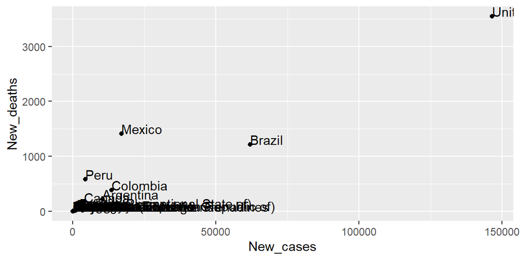

# 6.Inferential Analysis

## 6.2 Assumptions about the model

The assumptions about two-way anova are below:

1.The response variable in each group basically follow normal distribution.

2.The variance of each group is essentially the same.

3.Observations are independent of each group and within-group observations are obtained from a random sample.

## 6.3 Transformation in response variable.

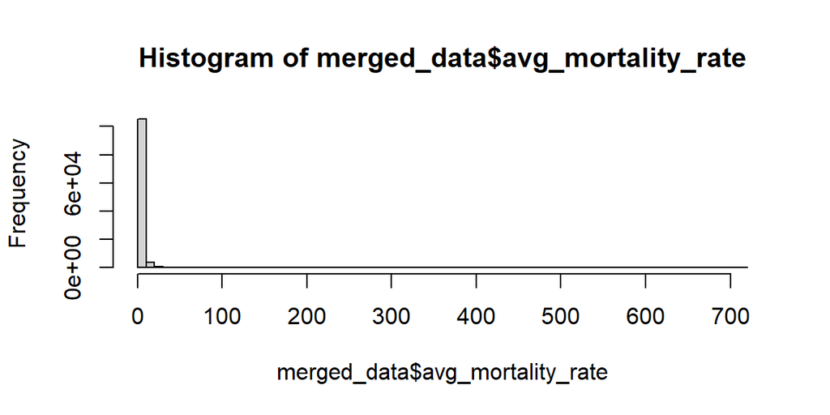

According to the histogram of response variable, I find that it need a transformation because of normality valid.

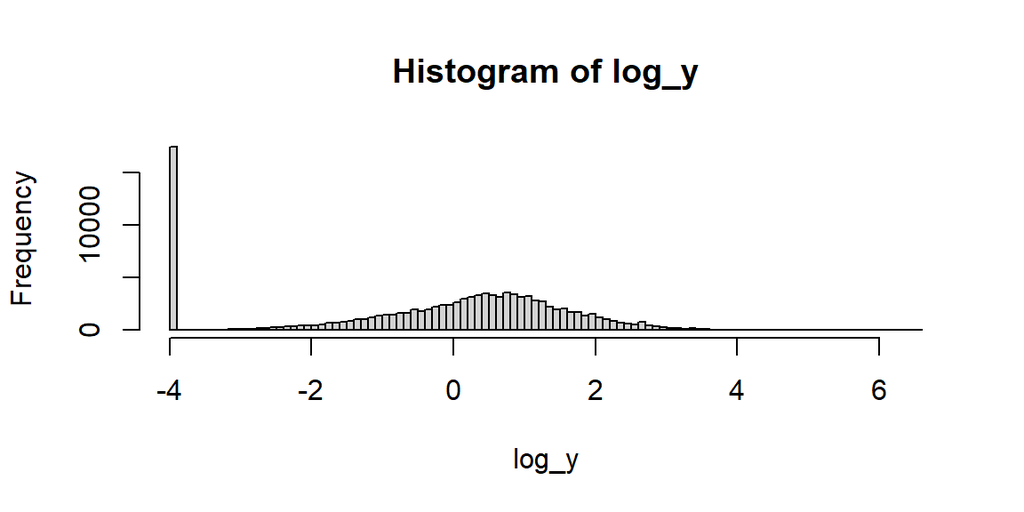

## 6.4 Select model by using average mortailty rate

Using F-test to solve the question below mentioned. Firstly. suppose that we are interested in testing the presence of interactions. Null hypothesis is
$$H_o:(\alpha\beta)_{ij}=0$$
Alternative hypothesis is
$$H_1:not\ all\ (\alpha\beta)_{ij}\ are\ zero$$
Thus,
$$\ Full\ model:Y_{ijk}=\mu_{..}+\alpha_i+\beta_j+(\alpha\beta)_{ij}+\epsilon_{ijk}$$
$$\ Reduced\ model:Y_{ijk}=\mu_{..}+\alpha_i+\beta_j+\epsilon_{ijk}$$

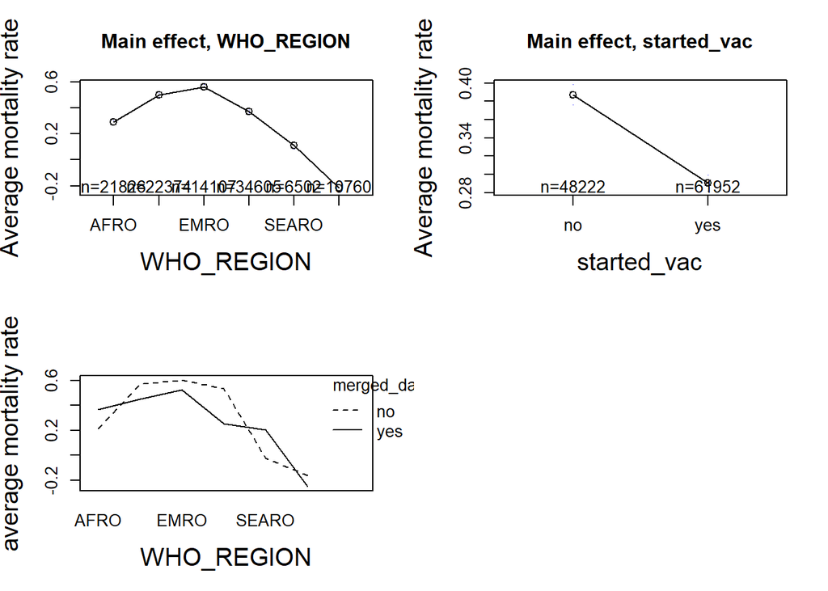

```
## Analysis of Variance Table
##
## Model 1: log_y ~ as.factor(WHO_REGION) + as.factor(started_vac)
## Model 2: log_y ~ as.factor(WHO_REGION) + as.factor(started_vac) + as.factor(WHO_REGION) *
##     as.factor(started_vac)
##   Res.Df    RSS Df Sum of Sq      F    Pr(>F)
## 1 110167 147693
## 2 110162 146907  5    786.16 117.91 < 2.2e-16 ***
## ---
## Signif. codes:  0 '***' 0.001 '**' 0.01 '*' 0.05 '.' 0.1 ' ' 1
```

```
##                                                  Df Sum Sq Mean Sq F value
## as.factor(WHO_REGION)                             5   5016  1003.2   752.2
## as.factor(started_vac)                            1    203   203.0   152.2
## as.factor(WHO_REGION):as.factor(started_vac)      5    786   157.2   117.9
## Residuals                                    110162 146907     1.3
##                                              Pr(>F)
## as.factor(WHO_REGION)                        <2e-16 ***
## as.factor(started_vac)                       <2e-16 ***
## as.factor(WHO_REGION):as.factor(started_vac) <2e-16 ***
## Residuals
## ---
## Signif. codes:  0 '***' 0.001 '**' 0.01 '*' 0.05 '.' 0.1 ' ' 1
```

| **Characteristic** | **p-value** |
| --- | --- |
| as.factor(WHO_REGION) | <0.001 |
| as.factor(started_vac) | <0.001 |
| as.factor(WHO_REGION) * as.factor(started_vac) | <0.001 |

## 6.5 Tukey mathod to test started_vac

```
##
##   Simultaneous Tests for General Linear Hypotheses
##
## Multiple Comparisons of Means: Tukey Contrasts
##
##
## Fit: aov(formula = log_y ~ WHO_REGION + started_vac + WHO_REGION *
##     started_vac, data = merged_data)
##
## Linear Hypotheses:
##               Estimate Std. Error t value Pr(>|t|)
## yes - no == 0  0.14954    0.01563   9.565   <2e-16 ***
## ---
## Signif. codes:  0 '***' 0.001 '**' 0.01 '*' 0.05 '.' 0.1 ' ' 1
## (Adjusted p values reported -- single-step method)
```

For the secondary question of interest, using Tukey-Kramer method to test the effect of vaccination. The null hypothesis is
$$\mu_1=\mu_2$$
The alternative hypothesis is
$$not\ all\ \mu \ are\ equal$$
From Simultaneous Tests for General Linear Hypotheses, I find that p-value<2e-16 is very small and it can reject the null hypothesis from linear hypothesis about yes-no==0 .Thus, it is concluded that the vaccine has some influence.

# 7.Sensitivity Analysis

## 7.1 diagnostic plots

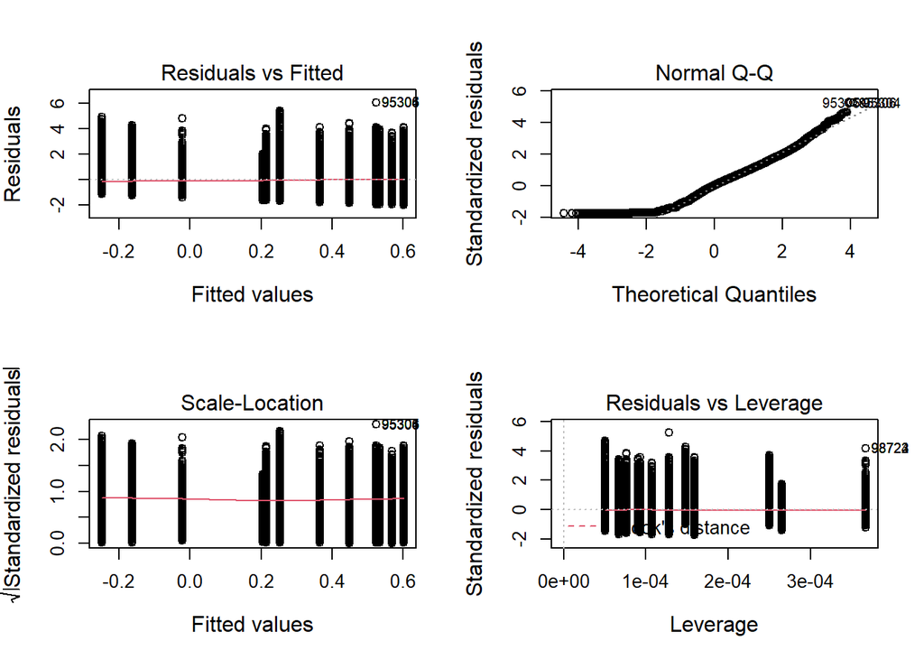